# Wednesday, November 4th, 2026

### Dealing with edge pixels

With the simple filters written above, we have ignored filtering pixels along the edge of the image. Let's try to deal with them now.

The [project page](https://jllottes.github.io/Projects/image_denoising/image_denoising.html#edge-pixels) discusses adding extra rows/columns to our array so that we are able to construct a `3` by `3` grid centered at all pixels of our original image.

If we are using `3` by `3` grids, we need to add one extra row/column on all sides. Our strategy then is to:

- Create an array `padded_img` that has two additional rows and two additional columns than the `noisy_img` array;
- Place the contents of the `noisy_img` array into a slice of the `padded_img` array that skips the first and last rows and first and last columns;
- Apply the the mean/median filter to each of the non-edge pixels of the `padded_img` (which corresponds to applying the filter to every pixel of the `noisy_img` array).

```python
noisy_img = noisy_circuit.copy()
nrows, ncols = noisy_img.shape
```

```python
padded_img = np.zeros((nrows + 2, ncols + 2))  # Create a new array with 2 extra rows and 2 extra columns

padded_img[1:-1, 1:-1] = noisy_img     # Set the original noisy_img array into the interior of padded_img
```

Let's take a closer look at one corner of the `padded_img` array:

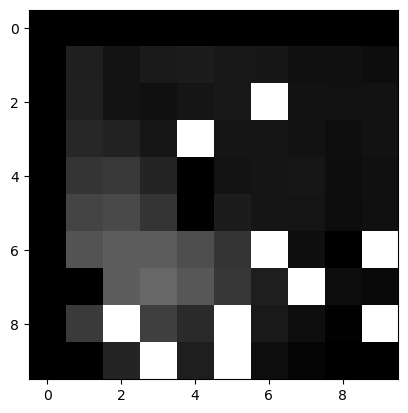

```python
plt.imshow(padded_img[:10,:10], cmap='gray', vmin=0, vmax=1)
```

Now, we want to use the `padded_img` array to build our `3` by `3` grids for computing means/medians. Let's copy in our median filter code and make any necessary changes.

```python
median_filtered_img = noisy_img.copy()
nrows, ncols = noisy_img.shape

for i in range(nrows):     # For every row
    for j in range(ncols): # For every column
        grid = padded_img[i:i+3, j:j+3]        # Build a 3x3 grid center on pixel i,j of noisy_img
        grid_median = np.median(grid)
        median_filtered_img[i,j] = grid_median # Set i,j-th filtered pixel to median of the 3x3 grid
```

```
(np.float64(-0.5), np.float64(639.5), np.float64(425.5), np.float64(-0.5))
```

[figure not shown]

```python
plt.imshow(median_filtered_img, cmap='gray', vmin=0, vmax=1)
plt.axis('off') # This will remove x and y ticks and labels
```

*Note*: We have added black border to the `padded_img` (since we used `np.zeros`), which propogates into the `filtered_img` when we take any mean that includes padded pixels. We could instead add a white border (by using `np.ones`), but that's not any better. We could split the difference by using `np.ones(...)/2` to use a gray border. For the project, it might be a good idea to think of other ways that one could deal with filtering pixels along the edges.

Let's try to turn the sample code above into some functions that we can use more broadly.

**Exercise:** Write a function `get_padded_img(img, pad)` that takes in a 2D array `img` and returns a padded array that adds `pad` rows at the top, bottom, left, and right of the array. That is, the `padded_img` array should have `2*pad` extra rows and `2*pad` extra columns.

```python
def imshow_gray(img):
    plt.imshow(img, cmap='gray', vmin=0, vmax=1)
```

[figure not shown]

```python
imshow_gray(noisy_img)
```

**Exercise:** Write a function `median_filter_with_edges` that takes in a noisy image array and applies the mean/median filter to every pixel (including edges) using a `3` by `3` grid.